# Comparing the BAIT and soundecology implementations of ACI at the clump level

This code is part of the verification of the BAIT implementation of the ACI algorithm by testing it against the results from the soundecology `acoustic_complexity` function. Because the FFT produced by BAIT is slightly different than that produced by the `spectro` function of seewave (used in `acoustic_complexity`), we use FFT values logged by test code on BAIT to compare the clump calculations.

# Setup

Much of this section duplicates code from the soundecology package’s `acoustic_complexity` function, modifying it to use FFT values pre-computed by BAIT and loaded from a CSV file.

## Load the libraries

```r
library(tuneR)
library(seewave)
library(soundecology)
library(tidyverse)
```

```r
library(ggplot2)
```

## Load the Data from BAIT

Loads the total ACI value calculated by BAIT (`bait_aci`), the clump ACI values (`bait_clump_data`)

```r
bait_aci <- read.csv(paste("./aci_clumps/ACI.CSV", sep=""), header=FALSE)$V2
bait_clump_data <- read.csv(paste("./aci_clumps/ACI_TW.CSV", sep=""))
bait_clump_sums <- diff(c(0, bait_clump_data$ACI_j))
timings <- bait_clump_data$frame
```

## Initialize the variables

These are already known from the wave files used or from pre-selected settings.

```r
min_freq <- 0
max_freq <- 44100/2
j <- 5
fft_w <- 256

samplingrate <- 44100
duration <- 50
nyquist_freq <- (samplingrate/2)
if (max_freq > nyquist_freq) {
    cat(paste("\n WARNING: The maximum acoustic frequency that this file can use is ",
        nyquist_freq, "Hz. But the script was set to measure up to ",
        max_freq, "Hz. The value of max_freq was changed to ",
        nyquist_freq, ".\n\n", sep = ""))
    max_freq <- nyquist_freq
}
wlen = fft_w
```

## get_d function

Calculates $D=\sum^n_{k=1} d_k$ where $d_k=|I_k - I_{(k+1)}|$. `min_col` and `max_col` are effectively `k` and `N` in this equation.

```r
get_d <- function(spectrum, freq_row, min_col, max_col) {
    D = 0
    for (k in min_col:(max_col - 1)) {
        D = D + abs(spectrum[freq_row, k] - spectrum[freq_row,
            k + 1])
    }
    return(D)
}
```

## Open the FFT file

Here, `acoustic_complexity` would normally process an audio file using `spectro` to extract an FFT. Here, we load it from the FFT calculated by BAIT.

```r
FFT <- read.csv(paste("./aci_clumps/FFT.CSV", sep=""), header=FALSE)
FFT_t <- t(FFT)
FFT_t <- head(FFT_t, -1)

spec_left <- list(time=seq(0,50,length.out = dim(FFT_t)[2]), freq=seq(0,22.1,length.out = dim(FFT_t)[1]), amp=FFT_t)
specA_left <- spec_left$amp
```

## Parameter calculations

```r
specA_rows <- dim(specA_left)[1] # Freq bins
specA_cols <- dim(specA_left)[2] # Time bins
fl <- rep(NA, specA_rows)
delta_fl <- (max_freq - min_freq)/specA_rows # Hz per bin
delta_tk <- duration/specA_cols # time per bin
no_j <- length(timings)
```

## Setting up empty containers

```r
ACI_left_vals <- rep(NA, no_j)
ACI_fl_left_vector <- rep(NA, no_j)
ACI_left_matrix <- data.frame(matrix(NA, nrow = specA_rows,
    ncol = no_j))
ACI_right_vals <- rep(NA, no_j)
ACI_fl_right_vector <- rep(NA, no_j)
ACI_right_matrix <- data.frame(matrix(NA, nrow = specA_rows,
    ncol = no_j))
```

# ACI Calculations

This code is looped for every cluster in every frequency bin. D is $D$. `sum_I` is $\sum^n_{k=1} I_k$ Those are totalled over all clusters and frequencies as `ACI_tot_left`.

Note in here, there is no manipulation of the spectrogram and no subsequent filtering of the data.

There was a problem with the original code, using the FFT data from BAIT. When all of the FFT measurements in a cluster are 0, you get $D=0$ and $\sum^n_{k=1} I_k = 0$. This causes a NAN for that $ACI_{j,\Delta fl}$, which causes a NAN for the whole ACI calculation. Note that this does not seem to occur when using FFTs from spectro because it is not accounted for in the code. I have modified the code to flip those NAN to 0. The logic behind this is that if each of the $I_k$ was a small, positive number, you would get $d_k=0$ for each step. At the same time, $\sum^n_{k=1} I_k > 0$ and so you would get $ACI_{\Delta fl}=0$.

```r
for (q_index in 1:specA_rows) { # For every frequency bin
    for (j_index in 1:no_j) { # For every cluster
        # min_col <- j_index * I_per_j - I_per_j + 1 # Cluster min bin
        # max_col <- j_index * I_per_j # Cluster max bin
      min_col <- c(1, timings)[j_index]
      max_col <- timings[j_index]

        # cat("Cluster ", q_index, ": [", min_col, ", ", max_col, "]\n")

        D <- get_d(specA_left, q_index, min_col, max_col) # Get cluster D
        sum_I <- sum(specA_left[q_index, min_col:max_col]) # Get Sum of I for cluster
        ACI_left_vals[j_index] <- D/sum_I
        ACI_left_matrix[q_index, j_index] <- D/sum_I

        ##### ADDED CODE TO DEAL WITH sum_I = 0 #####
        if (is.na(ACI_left_vals[j_index])){
          ACI_left_vals[j_index] <- 0
          ACI_left_matrix[q_index, j_index] <- 0
        }
        ###########

    }
    ACI_fl_left_vector[q_index] <- sum(ACI_left_vals)
}
ACI_tot_left <- sum(ACI_fl_left_vector)

aci_cluster_sums <- colSums(ACI_left_matrix)
```

# Print the results

```r
cat("Soundecology:")
cat("\nAcoustic Complexity Index (total): ")
cat(ACI_tot_left)

cat("\nCluster Sums: ")
cat( aci_cluster_sums )

cat("\n\nBAIT")
cat("\nAcoustic Complexity Index (total): ")
cat(bait_aci)

cat("\nCluster Sums: ")
cat(bait_clump_sums)
```

```
## Soundecology:
## Acoustic Complexity Index (total): 658.4267
## Cluster Sums: 57.40342 57.0539 56.78735 56.76687 56.22108 57.3697 53.45592 49.87974 52.63628 51.87855 56.84387 52.13003
##
## BAIT
## Acoustic Complexity Index (total): 662.8716
## Cluster Sums: 57.68345 57.25505 56.85101 56.99686 56.58998 57.56113 54.49112 50.93765 52.9321 52.08783 57.15363 52.33185
```

# Plot the results

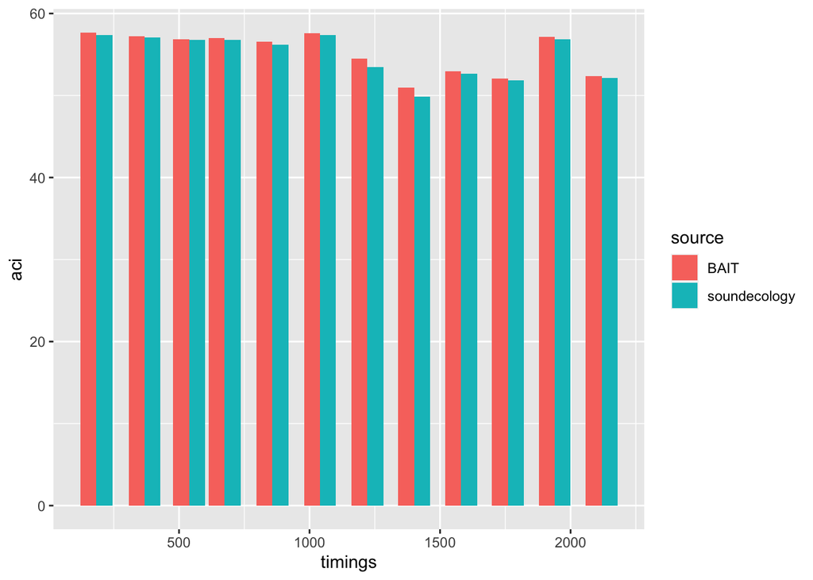

```r
aci_df <- data.frame(aci_cluster_sums, bait_clump_sums, timings, row.names = 1:no_j)
names(aci_df) <- c("soundecology", "BAIT", "timings")
aci_long_df <- aci_df %>% pivot_longer(!timings, names_to="source", values_to="aci")

ggplot(aci_long_df, aes(fill=source, y=aci, x=timings)) + geom_bar(position="dodge", stat="identity")
```

```r
ggtitle("ACI Cluster Sums ($ACI_j$)")
```

```
## $title
## [1] "ACI Cluster Sums ($ACI_j$)"
##
## attr(,"class")
## [1] "labels"
```